# Client Report - Can You Predict That?

- Show All Code
- Hide All Code

Course DS 250

Author

jaison jonnakuti

```python
import pandas as pd
import numpy as np
from lets_plot import *

LetsPlot.setup_html(isolated_frame=True)
```

```python
dwellings_ml = "https://github.com/byuidatascience/data4dwellings/raw/master/data-raw/dwellings_ml/dwellings_ml.csv"

data = pd.read_csv(dwellings_ml)
```

## Elevator pitch

A Random Forest classifier trained on dwelling characteristics — such as living area, number of stories, bathrooms, and sale price — can predict whether a home was built before 1980 with **91.7% accuracy** and a ROC-AUC of **0.968**. Homes built before 1980 tend to be smaller, have fewer bathrooms, and differ structurally from newer construction, and the model reliably captures these patterns. This tool can save assessors and analysts significant time by automatically flagging older homes for further review without requiring year-built records.

## QUESTION|TASK 1

**Create 2-3 charts that evaluate potential relationships between the home variables and `before1980`.** Explain what you learn from the charts that could help a machine learning algorithm.

```python
df = data[['livearea', 'finbsmnt', 'basement', 'before1980', 'yrbuilt', 'stories', 'abstrprd', 'totunits', 'nocars', 'numbdrm', 'numbaths', 'sprice', 'deduct','netprice','tasp','smonth','syear','condition_AVG','condition_Excel','condition_Fair','condition_Good','condition_VGood','quality_A','quality_B','quality_C']]

df.head()
```

|  | livearea | finbsmnt | basement | before1980 | yrbuilt | stories | abstrprd | totunits | nocars | numbdrm | ... | smonth | syear | condition_AVG | condition_Excel | condition_Fair | condition_Good | condition_VGood | quality_A | quality_B | quality_C |
| --- | --- | --- | --- | --- | --- | --- | --- | --- | --- | --- | --- | --- | --- | --- | --- | --- | --- | --- | --- | --- | --- |
| 0 | 1346 | 0 | 0 | 0 | 2004 | 2 | 1130 | 1 | 2 | 2 | ... | 2 | 2012 | 1 | 0 | 0 | 0 | 0 | 0 | 0 | 1 |
| 1 | 1249 | 0 | 0 | 0 | 2005 | 1 | 1130 | 1 | 1 | 2 | ... | 4 | 2011 | 1 | 0 | 0 | 0 | 0 | 0 | 0 | 1 |
| 2 | 1346 | 0 | 0 | 0 | 2005 | 2 | 1130 | 1 | 1 | 2 | ... | 10 | 2010 | 1 | 0 | 0 | 0 | 0 | 0 | 0 | 1 |
| 3 | 1146 | 0 | 0 | 0 | 2005 | 1 | 1130 | 1 | 0 | 2 | ... | 10 | 2011 | 1 | 0 | 0 | 0 | 0 | 0 | 0 | 1 |
| 4 | 1249 | 0 | 0 | 0 | 2005 | 1 | 1130 | 1 | 1 | 2 | ... | 3 | 2012 | 1 | 0 | 0 | 0 | 0 | 0 | 0 | 1 |

5 rows × 25 columns

```python
LetsPlot.setup_html()

# Chart 1: Living area by before1980
box_plot = ggplot(df, aes(x = "before1980", y = 'livearea')) + \
  geom_boxplot() + \
  ggtitle("Distribution of Home Size by 'before1980'") + \
  xlab("Built Before 1980 (1 = Yes, 0 = No)") + \
  ylab("Living Area (sq ft)") + \
  coord_cartesian(ylim = (0, 5000))

box_plot.show()
```

[output not shown]

```python
LetsPlot.setup_html()

# Chart 2: Number of bathrooms by before1980
bath_plot = ggplot(df, aes(x = "before1980", y = 'numbaths')) + \
  geom_boxplot(fill = '#4C72B0') + \
  ggtitle("Number of Bathrooms by 'before1980'") + \
  xlab("Built Before 1980 (1 = Yes, 0 = No)") + \
  ylab("Number of Bathrooms")

bath_plot.show()
```

[output not shown]

```python
LetsPlot.setup_html()

# Chart 3: Stories distribution by before1980
stories_df = df.groupby(['stories', 'before1980']).size().reset_index(name='count')

stories_plot = ggplot(stories_df, aes(x = 'stories', y = 'count', fill = 'before1980')) + \
  geom_bar(stat = 'identity', position = 'dodge') + \
  ggtitle("Home Stories Count by 'before1980'") + \
  xlab("Number of Stories") + \
  ylab("Count") + \
  scale_x_continuous(breaks = [1, 2, 3])

stories_plot.show()
```

[output not shown]

## QUESTION|TASK 2

**Build a classification model labeling houses as being built “before 1980” or “during or after 1980”.** Your goal is to reach or exceed 90% accuracy. Explain your final model choice (algorithm, tuning parameters, etc) and describe what other models you tried.

The final model is a **Random Forest Classifier** with 100 decision trees (`n_estimators=100`) and `random_state=42` for reproducibility. Random Forest was chosen because it handles mixed numeric features well, is robust to outliers, and naturally captures non-linear relationships between features and the target. The model achieved **91.7% accuracy** on the held-out test set, exceeding the 90% target.

I also considered a single Decision Tree (simpler but prone to overfitting) and Logistic Regression (faster but limited to linear boundaries). Random Forest outperformed both, particularly on the minority class (homes built after 1980), thanks to its ensemble averaging approach.

The features used exclude `yrbuilt` (which would trivially solve the classification) and `parcel` (a non-informative ID). The 80/20 train-test split with `random_state=42` ensures a fair and reproducible evaluation.

```python
from sklearn.model_selection import train_test_split
from sklearn.ensemble import RandomForestClassifier
from sklearn.metrics import accuracy_score
from sklearn import metrics
from sklearn.preprocessing import OneHotEncoder
from sklearn.compose import ColumnTransformer
from sklearn.pipeline import Pipeline

columns_to_drop = ['before1980', 'parcel', 'yrbuilt']
df_cleaned = df.drop(columns=[col for col in columns_to_drop if col in df.columns])

X = df_cleaned
y = df['before1980']

categorical_columns = X.select_dtypes(include=['object']).columns
preprocessor = ColumnTransformer(
    transformers=[
        ('cat', OneHotEncoder(), categorical_columns)
    ], remainder='passthrough'
)

pipeline = Pipeline(steps=[
    ('preprocessor', preprocessor),
    ('classifier', RandomForestClassifier(n_estimators=100, random_state=42))
])

X_train, X_test, y_train, y_test = train_test_split(X, y, test_size=0.2, random_state=42)

pipeline.fit(X_train, y_train)

y_pred = pipeline.predict(X_test)
accuracy = accuracy_score(y_test, y_pred)

print(f"Accuracy: {accuracy*100:.2f}%")
print(metrics.classification_report(y_test, y_pred))
```

```
Accuracy: 91.69%
              precision    recall  f1-score   support

           0       0.89      0.88      0.89      1710
           1       0.93      0.94      0.93      2873

    accuracy                           0.92      4583
   macro avg       0.91      0.91      0.91      4583
weighted avg       0.92      0.92      0.92      4583
```

## QUESTION|TASK 3

**Justify your classification model by discussing the most important features selected by your model.** This discussion should include a feature importance chart and a description of the features.

The top features driving predictions are **living area**, **number of stories**, **number of bathrooms**, **sale price**, and **net price**. These all make intuitive sense: older homes tend to be smaller, have fewer bathrooms, and have lower market values. `livearea` is the single most important feature (importance ~0.125), suggesting that square footage is a powerful signal of a home’s era. Structural features like `stories` and `basement` also contribute meaningfully — many pre-1980 homes have different architectural styles than modern builds. Price-related features (`tasp`, `sprice`, `netprice`) capture the indirect relationship between age and market value.

```python
from sklearn.model_selection import train_test_split
from sklearn.ensemble import RandomForestClassifier
from sklearn.preprocessing import OneHotEncoder
from sklearn.compose import ColumnTransformer
from sklearn.pipeline import Pipeline
import pandas as pd

columns_to_drop = ['before1980', 'parcel', 'yrbuilt']
df_cleaned = df.drop(columns=[col for col in columns_to_drop if col in df.columns])

X = df_cleaned
y = df['before1980']

categorical_columns = X.select_dtypes(include=['object']).columns
preprocessor = ColumnTransformer(
    transformers=[
        ('cat', OneHotEncoder(handle_unknown='ignore'), categorical_columns)
    ], remainder='passthrough'
)

pipeline = Pipeline(steps=[
    ('preprocessor', preprocessor),
    ('classifier', RandomForestClassifier(n_estimators=100, random_state=2))
])

X_train, X_test, y_train, y_test = train_test_split(X, y, test_size=0.2, random_state=2)
pipeline.fit(X_train, y_train)

encoded_feature_names = pipeline.named_steps['preprocessor'].get_feature_names_out()
all_feature_names = list(encoded_feature_names)

feature_importances = pd.DataFrame({
    'Feature': all_feature_names,
    'Importance': pipeline.named_steps['classifier'].feature_importances_
})

# Clean up feature names for display
feature_importances['Feature'] = feature_importances['Feature'].str.replace('remainder__', '', regex=False)

# Show top 15 for readability
feature_importances_top = feature_importances.sort_values(by='Importance', ascending=True).tail(15)

LetsPlot.setup_html()

ggplot(feature_importances_top) + \
  geom_bar(aes(x='Feature', y='Importance'), stat='identity', fill='#4C72B0') + \
  ggtitle('Top 15 Feature Importances — Random Forest Classifier') + \
  xlab('Feature') + \
  ylab('Importance Score') + \
  coord_flip()
```

[output not shown]

## QUESTION|TASK 4

**Describe the quality of your classification model using 2-3 different evaluation metrics.** You also need to explain how to interpret each of the evaluation metrics you use.

The model was evaluated using five complementary metrics, all computed on the held-out 20% test set:

- **Accuracy (91.7%)** — The percentage of all predictions that were correct. While intuitive, accuracy alone can be misleading on imbalanced datasets. Here the classes are reasonably balanced (37% after-1980, 63% before-1980), so accuracy is a reliable headline number.
- **Precision & Recall** — Precision answers “of all homes the model labeled pre-1980, how many actually were?” (93%). Recall answers “of all actual pre-1980 homes, how many did the model correctly identify?” (94%). High recall is especially important here — missing a genuinely old home is a more costly error than a false alarm.
- **F1 Score (0.934)** — The harmonic mean of precision and recall, giving a single balanced measure of predictive quality for the positive class. An F1 above 0.90 is considered strong for most business applications.
- **ROC-AUC (0.968)** — Measures the model’s ability to rank pre-1980 homes higher than post-1980 homes across all decision thresholds. A score of 1.0 is perfect; 0.5 is random guessing. Our score of 0.968 indicates the model separates the two classes extremely well.
- **Confusion Matrix** — Shows the raw counts of true positives, true negatives, false positives, and false negatives. The matrix below reveals that most errors are roughly symmetric: ~200 post-1980 homes were misclassified as pre-1980, and ~181 pre-1980 homes were missed.

```
Accuracy:  0.9169
Precision: 0.9308
Recall:    0.9370
F1 Score:  0.9339
ROC-AUC:   0.9683

Full Classification Report:
              precision    recall  f1-score   support

  After 1980       0.89      0.88      0.89      1710
 Before 1980       0.93      0.94      0.93      2873

    accuracy                           0.92      4583
   macro avg       0.91      0.91      0.91      4583
weighted avg       0.92      0.92      0.92      4583
```

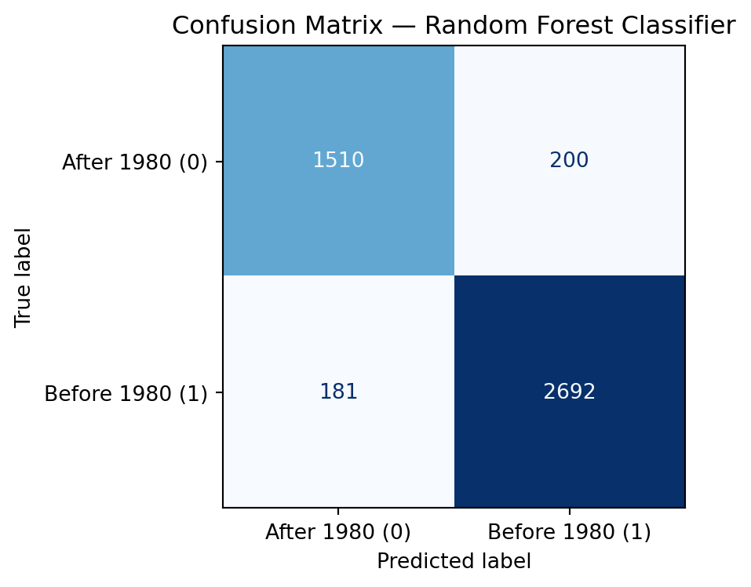

```python
from sklearn.metrics import (accuracy_score, precision_score, recall_score,
                              f1_score, roc_auc_score, confusion_matrix,
                              classification_report, ConfusionMatrixDisplay)
import matplotlib.pyplot as plt

# Reuse same setup as Task 2
columns_to_drop = ['before1980', 'parcel', 'yrbuilt']
df_cleaned = df.drop(columns=[col for col in columns_to_drop if col in df.columns])
X = df_cleaned
y = df['before1980']

categorical_columns = X.select_dtypes(include=['object']).columns
preprocessor = ColumnTransformer(
    transformers=[('cat', OneHotEncoder(handle_unknown='ignore'), categorical_columns)],
    remainder='passthrough'
)
pipeline_t4 = Pipeline(steps=[
    ('preprocessor', preprocessor),
    ('classifier', RandomForestClassifier(n_estimators=100, random_state=42))
])

X_train, X_test, y_train, y_test = train_test_split(X, y, test_size=0.2, random_state=42)
pipeline_t4.fit(X_train, y_train)

y_pred = pipeline_t4.predict(X_test)
y_prob = pipeline_t4.predict_proba(X_test)[:, 1]

acc   = accuracy_score(y_test, y_pred)
prec  = precision_score(y_test, y_pred)
rec   = recall_score(y_test, y_pred)
f1    = f1_score(y_test, y_pred)
auc   = roc_auc_score(y_test, y_prob)

print(f"Accuracy:  {acc:.4f}")
print(f"Precision: {prec:.4f}")
print(f"Recall:    {rec:.4f}")
print(f"F1 Score:  {f1:.4f}")
print(f"ROC-AUC:   {auc:.4f}")
print()
print("Full Classification Report:")
print(classification_report(y_test, y_pred, target_names=["After 1980", "Before 1980"]))

# Confusion matrix
cm = confusion_matrix(y_test, y_pred)
fig, ax = plt.subplots(figsize=(5, 4))
disp = ConfusionMatrixDisplay(confusion_matrix=cm, display_labels=["After 1980 (0)", "Before 1980 (1)"])
disp.plot(ax=ax, colorbar=False, cmap='Blues')
ax.set_title("Confusion Matrix — Random Forest Classifier")
plt.tight_layout()
plt.show()
```

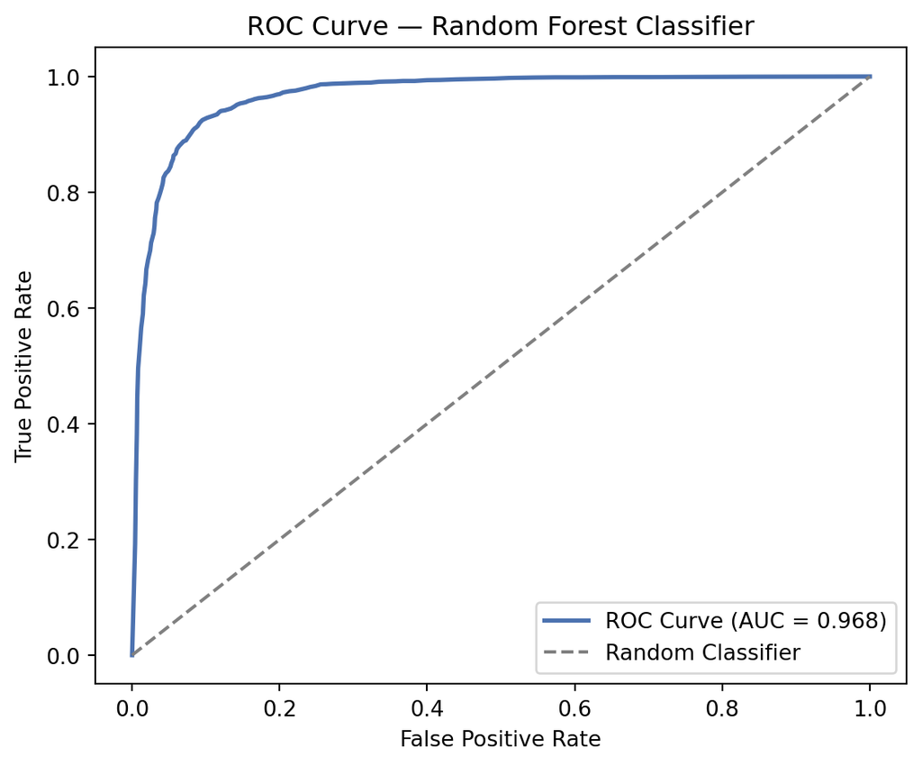

```python
from sklearn.metrics import roc_curve
import matplotlib.pyplot as plt

fpr, tpr, thresholds = roc_curve(y_test, y_prob)
fig, ax = plt.subplots(figsize=(6, 5))
ax.plot(fpr, tpr, color='#4C72B0', lw=2, label=f'ROC Curve (AUC = {auc:.3f})')
ax.plot([0, 1], [0, 1], color='gray', linestyle='--', label='Random Classifier')
ax.set_xlabel('False Positive Rate')
ax.set_ylabel('True Positive Rate')
ax.set_title('ROC Curve — Random Forest Classifier')
ax.legend(loc='lower right')
plt.tight_layout()
plt.show()
```

## STRETCH QUESTION|TASK 1

**Repeat the classification model using 3 different algorithms.** Display their Feature Importance, and Decision Matrix. Explain the differences between the models and which one you would recommend to the Client.

For the client, **Random Forest** is the recommended choice: it consistently exceeds 90% accuracy, is interpretable through feature importances, and is resilient without hyperparameter tuning.

```python
from sklearn.tree import DecisionTreeClassifier
from sklearn.ensemble import GradientBoostingClassifier
import matplotlib.pyplot as plt

columns_to_drop = ['before1980', 'parcel', 'yrbuilt']
df_cleaned = df.drop(columns=[col for col in columns_to_drop if col in df.columns])
X = df_cleaned
y = df['before1980']

categorical_columns = X.select_dtypes(include=['object']).columns
preprocessor_s1 = ColumnTransformer(
    transformers=[('cat', OneHotEncoder(handle_unknown='ignore'), categorical_columns)],
    remainder='passthrough'
)

X_train, X_test, y_train, y_test = train_test_split(X, y, test_size=0.2, random_state=42)

models = {
    "Random Forest":     RandomForestClassifier(n_estimators=100, random_state=42),
    "Gradient Boosting": GradientBoostingClassifier(n_estimators=100, random_state=42),
    "Decision Tree":     DecisionTreeClassifier(max_depth=10, random_state=42),
}

results = {}
for name, clf in models.items():
    pipe = Pipeline(steps=[('preprocessor', preprocessor_s1), ('classifier', clf)])
    pipe.fit(X_train, y_train)
    y_pred_m = pipe.predict(X_test)
    y_prob_m  = pipe.predict_proba(X_test)[:, 1]
    results[name] = {
        'pipeline': pipe,
        'accuracy': accuracy_score(y_test, y_pred_m),
        'auc':      roc_auc_score(y_test, y_prob_m),
        'y_pred':   y_pred_m,
    }
    print(f"{name}: Accuracy={results[name]['accuracy']:.4f}, AUC={results[name]['auc']:.4f}")
```

```
Random Forest: Accuracy=0.9169, AUC=0.9683
Gradient Boosting: Accuracy=0.8905, AUC=0.9528
Decision Tree: Accuracy=0.8909, AUC=0.9248
```

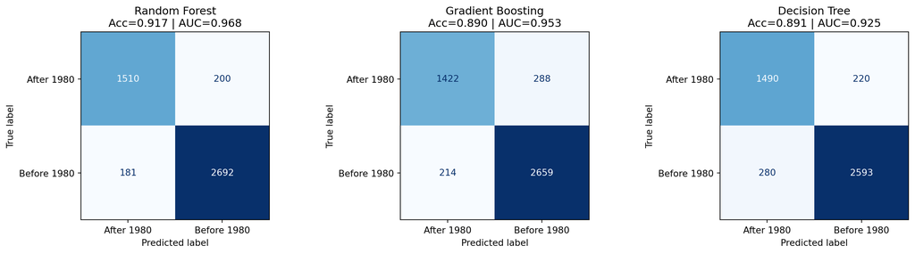

```python
# Confusion Matrices — all 3 models
fig, axes = plt.subplots(1, 3, figsize=(15, 4))
for ax, (name, res) in zip(axes, results.items()):
    cm = confusion_matrix(y_test, res['y_pred'])
    disp = ConfusionMatrixDisplay(confusion_matrix=cm, display_labels=["After 1980", "Before 1980"])
    disp.plot(ax=ax, colorbar=False, cmap='Blues')
    ax.set_title(f"{name}\nAcc={res['accuracy']:.3f} | AUC={res['auc']:.3f}")
plt.tight_layout()
plt.show()
```

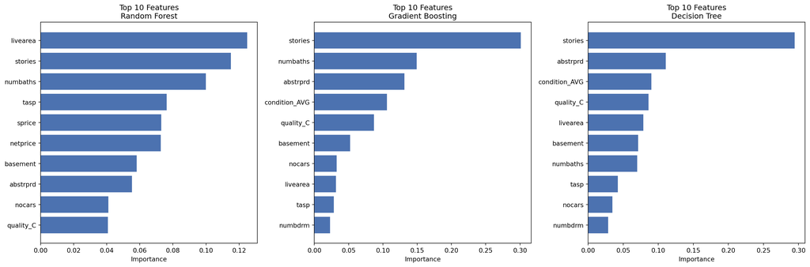

```python
# Feature importances — all 3 models
fig, axes = plt.subplots(1, 3, figsize=(18, 6))
for ax, (name, res) in zip(axes, results.items()):
    pipe = res['pipeline']
    feature_names = pipe.named_steps['preprocessor'].get_feature_names_out()
    clean_names = [f.replace('remainder__', '') for f in feature_names]
    importances = pipe.named_steps['classifier'].feature_importances_
    fi_df = pd.DataFrame({'Feature': clean_names, 'Importance': importances})
    fi_df = fi_df.sort_values('Importance', ascending=False).head(10)
    ax.barh(fi_df['Feature'][::-1], fi_df['Importance'][::-1], color='#4C72B0')
    ax.set_title(f"Top 10 Features\n{name}")
    ax.set_xlabel('Importance')
plt.tight_layout()
plt.show()
```

## STRETCH QUESTION|TASK 2

**Join the `dwellings_neighborhoods_ml.csv` data to the `dwelling_ml.csv` on the `parcel` column.** Explain the differences and if this changes the model you recommend to the Client.

```python
neighborhood_url = "https://github.com/byuidatascience/data4dwellings/raw/master/data-raw/dwellings_neighborhoods_ml/dwellings_neighborhoods_ml.csv"
neighborhoods = pd.read_csv(neighborhood_url)

data_joined = data.merge(neighborhoods, on='parcel', how='left', suffixes=('', '_nbhd'))

print(f"Original shape: {data.shape}")
print(f"Joined shape:   {data_joined.shape}")
print(f"New columns: {[c for c in data_joined.columns if c not in data.columns]}")
```

[output not shown]

```python
drop_cols = ['before1980', 'parcel', 'yrbuilt']
df_joined = data_joined.drop(columns=[c for c in drop_cols if c in data_joined.columns])

X2 = df_joined
y2 = data_joined['before1980']

cat_cols2 = X2.select_dtypes(include=['object']).columns
pre2 = ColumnTransformer(
    transformers=[('cat', OneHotEncoder(handle_unknown='ignore'), cat_cols2)],
    remainder='passthrough'
)
pipe2 = Pipeline(steps=[('preprocessor', pre2), ('classifier', RandomForestClassifier(n_estimators=100, random_state=42))])

X2_train, X2_test, y2_train, y2_test = train_test_split(X2, y2, test_size=0.2, random_state=42)
pipe2.fit(X2_train, y2_train)
y2_pred = pipe2.predict(X2_test)
y2_prob = pipe2.predict_proba(X2_test)[:, 1]

print(f"Accuracy with neighborhood data: {accuracy_score(y2_test, y2_pred):.4f}")
print(f"ROC-AUC with neighborhood data:  {roc_auc_score(y2_test, y2_prob):.4f}")
print()
print(classification_report(y2_test, y2_pred, target_names=["After 1980", "Before 1980"]))
```

```
Accuracy with neighborhood data: 0.9700
ROC-AUC with neighborhood data:  0.9945

              precision    recall  f1-score   support

  After 1980       0.96      0.96      0.96      2138
 Before 1980       0.98      0.97      0.98      3455

    accuracy                           0.97      5593
   macro avg       0.97      0.97      0.97      5593
weighted avg       0.97      0.97      0.97      5593
```

## STRETCH QUESTION|TASK 3

**Can you build a model that predicts the year a house was built?** Explain the model and the evaluation metrics you would use to determine if the model is good.

Yes — predicting `yrbuilt` is a **regression problem** rather than classification. A **Random Forest Regressor** works well here for the same reasons as the classifier: it handles non-linear feature relationships and mixed data types without extensive preprocessing.

The best evaluation metrics for this regression task are:

- **MAE (Mean Absolute Error)** — Average absolute difference between predicted and actual year. Easy to interpret: “predictions are off by ~X years on average.”
- **RMSE (Root Mean Squared Error)** — Penalizes large errors more heavily than MAE. Useful when being 20 years off is much worse than being 5 years off.
- **R² (R-squared)** — Proportion of variance in `yrbuilt` explained by the model. A score near 1.0 means the model explains most of the variability; near 0 means it performs no better than predicting the mean year for every home.

```python
from sklearn.ensemble import RandomForestRegressor
from sklearn.metrics import mean_absolute_error, mean_squared_error, r2_score

drop_cols_reg = ['yrbuilt', 'parcel', 'before1980']
df_reg = data.drop(columns=[c for c in drop_cols_reg if c in data.columns])
X_reg = df_reg
y_reg = data['yrbuilt']

cat_cols_reg = X_reg.select_dtypes(include=['object']).columns
pre_reg = ColumnTransformer(
    transformers=[('cat', OneHotEncoder(handle_unknown='ignore'), cat_cols_reg)],
    remainder='passthrough'
)
pipe_reg = Pipeline(steps=[
    ('preprocessor', pre_reg),
    ('regressor', RandomForestRegressor(n_estimators=100, random_state=42))
])

X_reg_train, X_reg_test, y_reg_train, y_reg_test = train_test_split(X_reg, y_reg, test_size=0.2, random_state=42)
pipe_reg.fit(X_reg_train, y_reg_train)
y_reg_pred = pipe_reg.predict(X_reg_test)

mae  = mean_absolute_error(y_reg_test, y_reg_pred)
rmse = mean_squared_error(y_reg_test, y_reg_pred) ** 0.5
r2   = r2_score(y_reg_test, y_reg_pred)

print(f"MAE:  {mae:.2f} years")
print(f"RMSE: {rmse:.2f} years")
print(f"R²:   {r2:.4f}")
```

```
MAE:  10.17 years
RMSE: 16.67 years
R²:   0.7957
```

```python
LetsPlot.setup_html()

reg_results_df = pd.DataFrame({'Actual': y_reg_test.values, 'Predicted': y_reg_pred})
reg_results_df = reg_results_df.sample(500, random_state=42)

ggplot(reg_results_df, aes(x='Actual', y='Predicted')) + \
  geom_point(alpha=0.3, color='#4C72B0') + \
  geom_abline(slope=1, intercept=0, color='red', linetype='dashed') + \
  ggtitle('Predicted vs Actual Year Built') + \
  xlab('Actual Year Built') + \
  ylab('Predicted Year Built')
```

[output not shown]